# European Parenting Leave Policies

Author

Jo Hardin

Published

June 2, 2026

# European Parenting Leave Policies

This week we’re exploring European Parenting Leave Policies. The European Parenting Leave Policies (EPLP) Dataset provides harmonised data on maternity, co-parent, paid parental, and job-protected leave regulations across 21 European countries from 1970 to 2024.

> The dataset enables quantitative analyses of policy trends, cross-national differences, and the effects of major reforms – for researchers, policymakers, and others interested in family policy.

Given the variety of parental leave schemes across countries, the dataset considers three different dimensions of parental leave duration for each country, if applicable. Dimension 1 (par1) identifies the paid parental leave scheme with the longest possible duration. Dimension 2 (par2) identifies the paid parental leave duration with the highest monthly flat rate payment. Dimension 3 (par3) identifies the duration with the highest replacement rate.

Values that are missing are represented as `NA`. Some values are missing because they are not applicable. These values are encoded as `"Not applicable"` for character vectors, and `-98` for numeric variables.

- Which countries were the first to implement co-parent leave policies?
- Has parenting leave decreased in any countries?

Cite the dataset as: S. Spitzer et al., “The European Parenting Leave Policies (EPLP) Dataset”. Zenodo, Nov. 19, 2025. doi: 10.5281/zenodo.17648712.

Thank you to [Nicola Rennie](https://github.com/nrennie) for curating this week’s dataset.

```r
library(tidyverse)
library(sf)
library(rnaturalearth)
library(gganimate)
library(magick)
library(praise)
library(broom)
```

```r
eplp <- readr::read_csv(
  'https://raw.githubusercontent.com/rfordatascience/tidytuesday/main/data/2026/2026-06-02/eplp.csv'
) |>
  mutate(across(where(is.numeric), ~ na_if(.x, -98))) # changes all of the -98 to NA
```

## Job-protected leave

Using the variable `job-protected leave duration for birth mothers (maximum duration)`, we consider changes across time and country. The variable measures the maximum length of time, after childbirth, that a birth mother is legally entitled to be absent from paid work while her job (or an equivalent position) is protected.

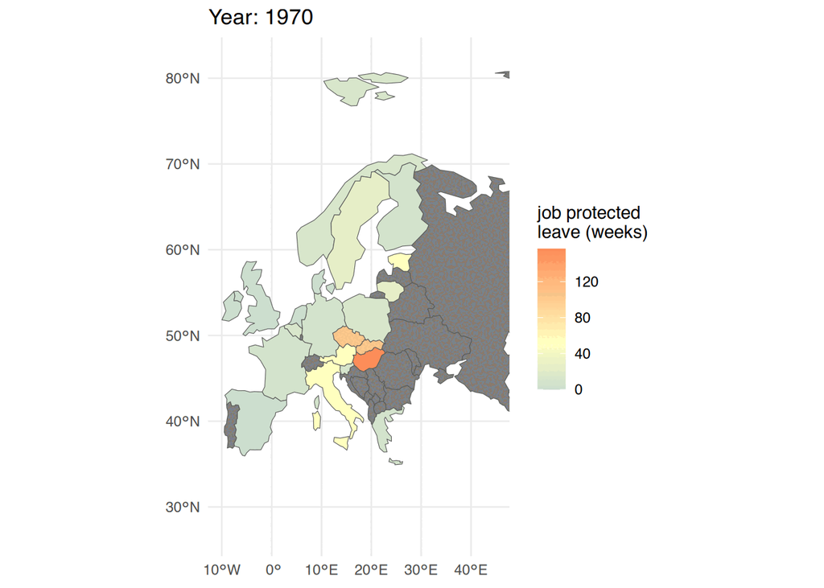

Over time most countries have increased their number of weeks of job protection.

```r
europe <- ne_countries(continent = "europe", returnclass = "sf")
yrs <- sort(unique(eplp$year))

p <- europe |>
  mutate(country2 = ifelse(iso_a2_eh == "GB", "UK", iso_a2_eh)) |>
  tidyr::expand_grid(year = yrs) |>
  st_as_sf() |>
  left_join(eplp, by = c("country2" = "country", "year")) |>
  ggplot() +
  geom_sf(aes(fill = jp_ld_m)) +
  coord_sf(xlim = c(-10, 45), ylim = c(27, 82)) +
  theme_minimal() +
  scale_fill_gradient2(
    low = "#91BFDB",
    mid = "#FFFFBF",
    high = "#FC8D59",
    name = "job protected \nleave (weeks)",
    midpoint = median(eplp$jp_ld_m, na.rm = TRUE)
  ) +
  transition_states(year, transition_length = 0, state_length = 4) +
  labs(title = "Year: {closest_state}")

animate(p)
```

# Predicting protected leave weeks

We can use a linear model and the following variables - `par1_ld` (paid parental leave duration ) and `year` and `par1_for_whom` (who is eligible for paid parental leave) - to predict `jd_ld_m` (job-protected leave duration for birth mothers ).

Caveat: from the scatterplot (and the residual plot below), it doesn’t seem like a linear model is necessarily the best model to fit here. That is, `jd_ld_m` is not really a linear model of the variables.

Running models one at a time to investigate the relationship between `part1_ld` and `par1_for_whom` in predicting `jp_ld_m`. We are only interested in predicting for those countries that actually have policies (i.e., where `part1_ld` $\ne 0$). Note that `par1_for_whom` is either `mothers` or `either`.

```r
eplp1 <- eplp |>
  filter(par1_ld != 0)
```

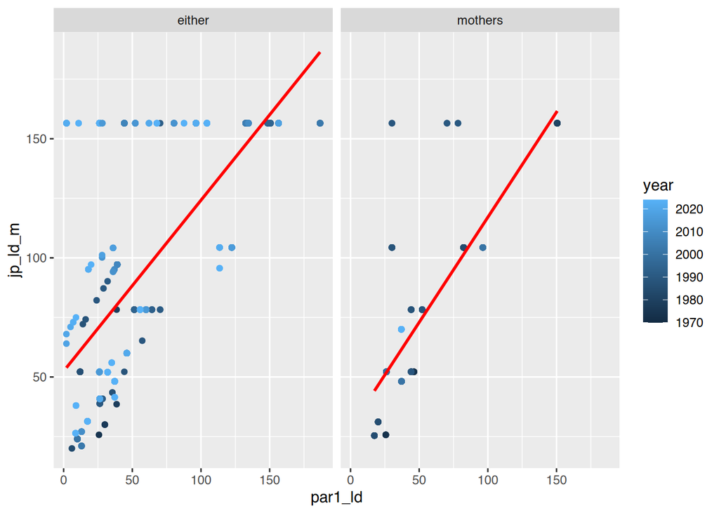

```r
eplp1 |>
  ggplot(aes(x = par1_ld, y = jp_ld_m, color = year)) +
  geom_point() +
  geom_smooth(method = "lm", se = FALSE, color = "red") +
  facet_wrap(~par1_for_whom)
```

Again, with the caveat that the relationship is not truly linear, it seems like both `par1_ld` and `par1_for_whom` are important in predicting `jp_ld_m`. Additionally, there seems to be moderate interaction between `par1_ld` and `par1_for_whom`.

```r
lm(jp_ld_m ~ par1_ld, data = eplp1) |>
  tidy()
```

```
# A tibble: 2 × 5
  term        estimate std.error statistic   p.value
  <chr>          <dbl>     <dbl>     <dbl>     <dbl>
1 (Intercept)   46.5      2.15        21.6 3.07e- 79
2 par1_ld        0.754    0.0281      26.8 7.65e-109
```

```r
lm(jp_ld_m ~ par1_ld + par1_for_whom, data = eplp1) |>
  tidy()
```

```
# A tibble: 3 × 5
  term                 estimate std.error statistic   p.value
  <chr>                   <dbl>     <dbl>     <dbl>     <dbl>
1 (Intercept)            50.9      2.30       22.1  3.34e- 82
2 par1_ld                 0.742    0.0277     26.8  1.75e-108
3 par1_for_whommothers  -14.4      2.94       -4.91 1.17e-  6
```

```r
lm(jp_ld_m ~ par1_ld * par1_for_whom, data = eplp1) |>
  tidy()
```

```
# A tibble: 4 × 5
  term                         estimate std.error statistic  p.value
  <chr>                           <dbl>     <dbl>     <dbl>    <dbl>
1 (Intercept)                    52.5      2.41       21.8  3.28e-80
2 par1_ld                         0.717    0.0300     23.9  3.06e-92
3 par1_for_whommothers          -23.6      5.22       -4.53 6.93e- 6
4 par1_ld:par1_for_whommothers    0.165    0.0774      2.13 3.33e- 2
```

To check whether it was reasonable to run a linear model, we produce a residual plot. As expected, the residuals are not particularly scattered (normally) around the `y = 0` line. So any inference drawn on the model should be done so with a grain of salt.

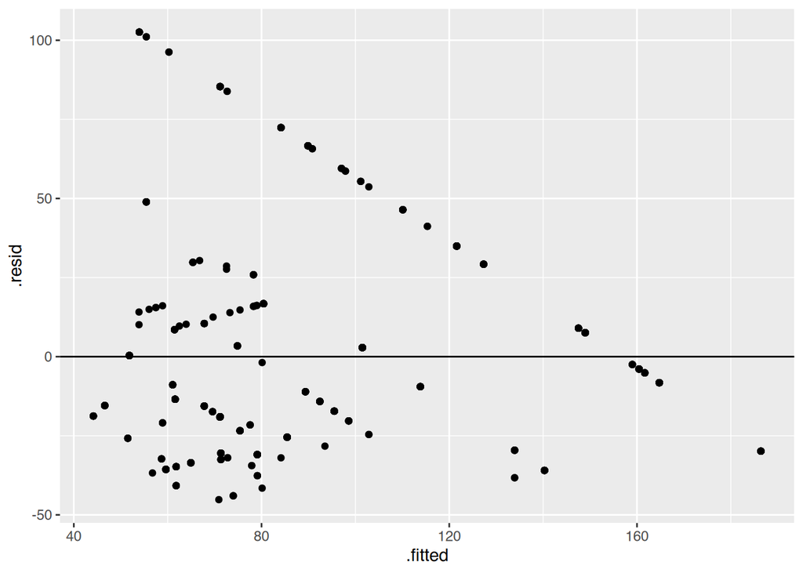

```r
lm(jp_ld_m ~ par1_ld * par1_for_whom, data = eplp1) |>
  augment() |>
  ggplot(aes(x = .fitted, y = .resid)) +
  geom_point() +
  geom_hline(yintercept = 0)
```

```r
praise()
```

```
[1] "You are sublime!"
```